# Day 19: ggtext

Welcome back for the 19th day of the [#packagecalendar](https://twitter.com/hashtag/packagecalendar), today we will be taking a look at the ggtext package by [Claus Wilke](https://twitter.com/ClausWilke). The **ggtext** package provides improved text rendering support for [ggplot2](https://ggplot2.tidyverse.org/).

The package is not yet available from CRAN but can be downloaded with

```r
remotes::install_github("clauswilke/ggtext")
```

For the following example, we will use the “Last Christmas” data from earlier posts.

```r
# remotes::install_github("PMassicotte/gtrendsR")
library(gtrendsR)
last_christmas <- gtrends("Last Christmas", time = "today 3-m")$interest_over_time
```

And we will be building off the chart we created back in [day 11](https://www.hvitfeldt.me/pkgcal2019/11/)

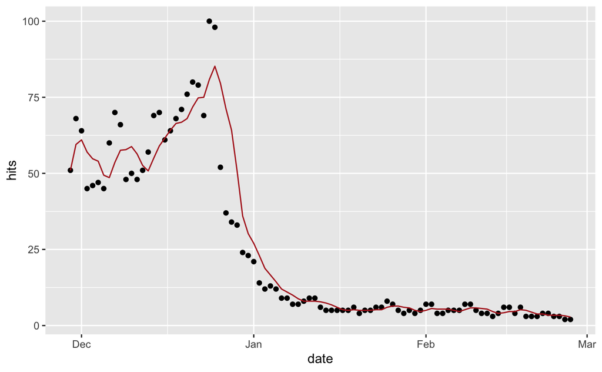

```r
library(ggplot2)
library(slide)
library(dplyr)
last_christmas %>%
  mutate(hits_ma5 = slide_dbl(hits, ~mean(.x), .before = 4)) %>%
  ggplot(aes(date, hits)) +
  geom_point() +
  geom_line(aes(y = hits_ma5), color = "firebrick")
```

**ggtext** introduces a new theme element, `element_markdown()`, which behaves similarly to `element_text()` but renders the text as markdown/HTML. Suppose you want to selectively bold part of our title. Using markdown we would put the text in double stars.

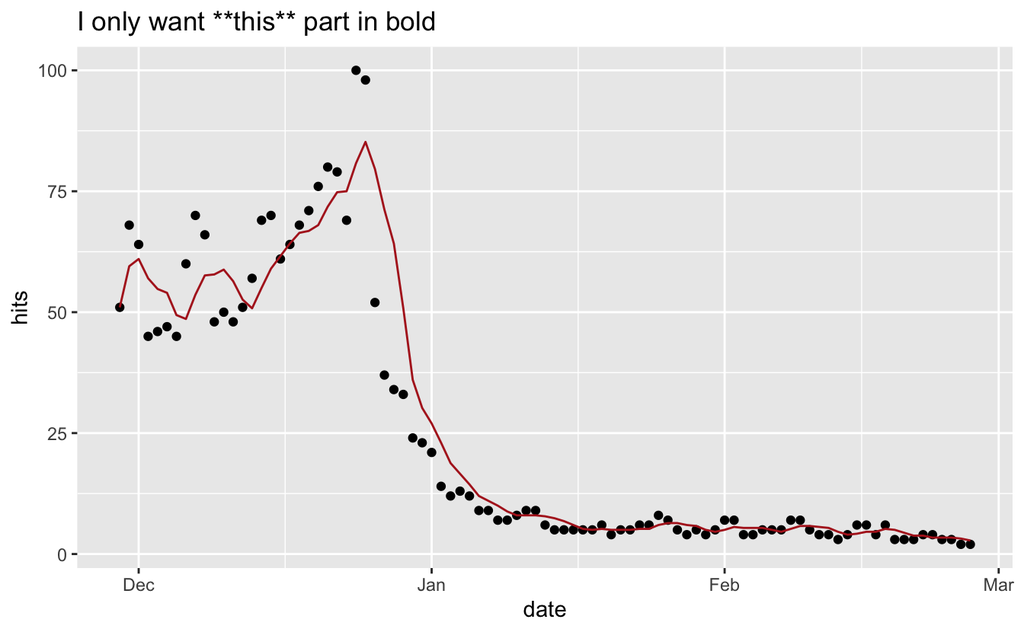

```r
last_christmas %>%
  mutate(hits_ma5 = slide_dbl(hits, ~mean(.x), .before = 4)) %>%
  ggplot(aes(date, hits)) +
  geom_point() +
  geom_line(aes(y = hits_ma5), color = "firebrick") +
  labs(title = "I only want **this** part in bold")
```

But using normal **ggplot2** doesn’t allow you to do that. There is where **ggtext** comes in, we use the `theme()` function to specify the plot title to be rendered using markdown.

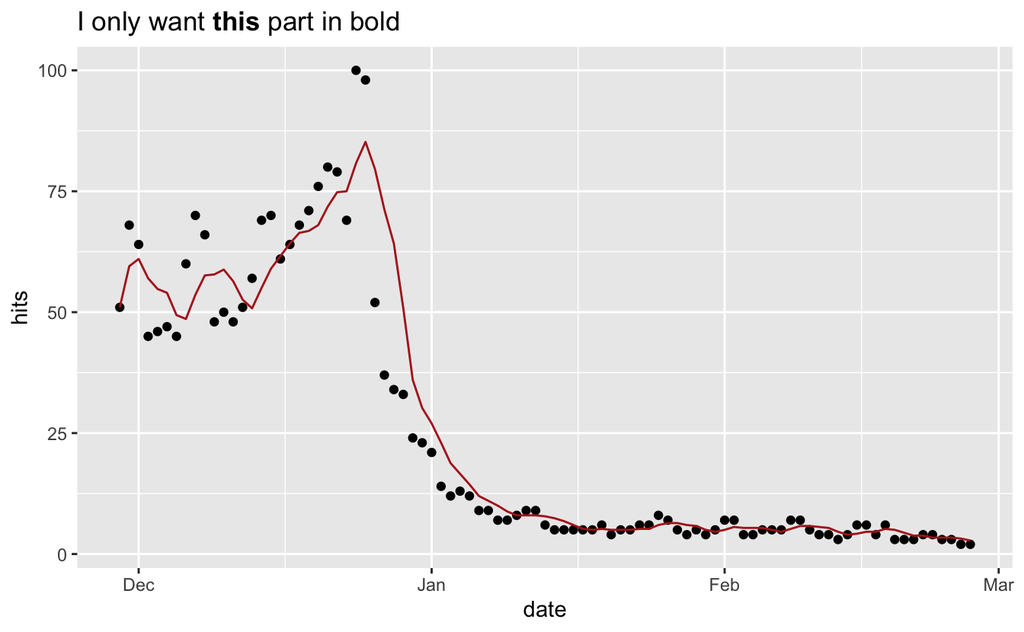

```r
library(ggtext)
last_christmas %>%
  mutate(hits_ma5 = slide_dbl(hits, ~mean(.x), .before = 4)) %>%
  ggplot(aes(date, hits)) +
  geom_point() +
  geom_line(aes(y = hits_ma5), color = "firebrick") +
  labs(title = "I only want **this** part in bold") +
  theme(plot.title = element_markdown())
```

Additionally, you can also use standard HTML syntax to modify your text

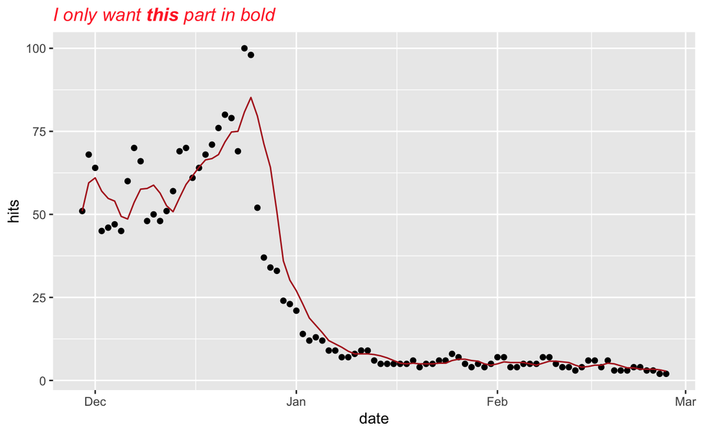

```r
last_christmas %>%
  mutate(hits_ma5 = slide_dbl(hits, ~mean(.x), .before = 4)) %>%
  ggplot(aes(date, hits)) +
  geom_point() +
  geom_line(aes(y = hits_ma5), color = "firebrick") +
  labs(title =  "<i style='color:#FF3030'>I only want **this** part in bold</i>") +
  theme(plot.title = element_markdown())
```